# Изучение закономерностей, определяющих успешность игр

### 3. Исследовательский анализ данных

К плану работ

### 3.1 Сколько игр выпускалось в разные годы? Важны ли данные за все периоды?

К плану работ

```python
# группируем количество релизов по годам выпуска
data2.groupby('year_of_release')['year_of_release'].agg('count')
```

```
year_of_release
1980       9
1981      46
1982      36
1983      17
1984      14
1985      14
1986      21
1987      16
1988      15
1989      17
1990      16
1991      41
1992      43
1993      60
```

[output cut: 24 more lines]

Агрегация по count() показала нам число игр, выпущенных на всех платформах, в разрезе лет. Т.е. если одна и та же игра (name) вышла в некоем году на одной платформе, агрегат == 1. Если на 2-х платформах, агрегат == 2, ну и так далее. Это неверно, поэтому, чтобы получить истинное количество «игр по годам» следует поискать дубликаты по (Годам - Названиям игр) и затем исключить из полного датафрейма все дубли за исключением одной, «первой», строки.

```python
# выделяем 2 столбца название игры и год релиза
data_year_game = data2[['year_of_release','name']]
```

```python
# выводим первые 5 строк таблицы
display(data_year_game.head())
```

|  | year_of_release | name |
| --- | --- | --- |
| 0 | 2006 | wii sports |
| 1 | 1985 | super mario bros. |
| 2 | 2008 | mario kart |
| 3 | 2009 | wii sports resort |
| 4 | 1996 | pokemon red/pokemon blue |

```python
# Смотрим информацию о полученной таблице
data2.info()
```

```
<class 'pandas.core.frame.DataFrame'>
RangeIndex: 16563 entries, 0 to 16562
Data columns (total 12 columns):
 #   Column           Non-Null Count  Dtype
---  ------           --------------  -----
 0   name             16563 non-null  object
 1   platform         16563 non-null  object
 2   year_of_release  16563 non-null  int64
 3   genre            16563 non-null  object
 4   na_sales         16563 non-null  float64
 5   eu_sales         16563 non-null  float64
 6   jp_sales         16563 non-null  float64
 7   other_sales      16563 non-null  float64
 8   critic_score     8071 non-null   float64
 9   user_score       7536 non-null   float64
 10  rating           16563 non-null  object
 11  total_sales      16563 non-null  float64
dtypes: float64(7), int64(1), object(4)
memory usage: 1.5+ MB
```

```python
#выводим на экран количество явных дубликатов
print('duplicates:',data_year_game.duplicated().sum())
```

```
duplicates: 4370
```

```python
#удаляем явные дубликаты
data_year_game = data_year_game.drop_duplicates()
```

```python
#выводим на экран количество явных дубликатов
print('duplicates_:',data_year_game.duplicated().sum())
```

```
duplicates_: 0
```

```python
# после удаления
# группируем по году выпуска
data_year_game.groupby('year_of_release')['year_of_release'].agg('count')
```

```
year_of_release
1980       9
1981      46
1982      36
1983      17
1984      14
1985      14
1986      21
1987      16
1988      15
1989      17
1990      16
1991      40
1992      41
1993      59
```

[output cut: 24 more lines]

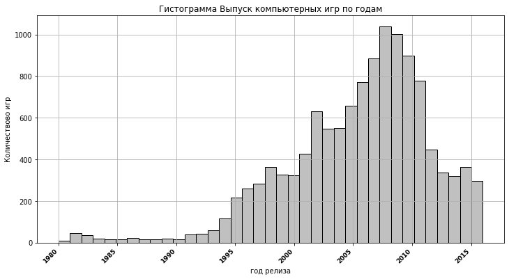

```python
# строим гистограмму
data_year_game['year_of_release'].plot(kind='hist', bins=37, ec='black',
                              color='silver', figsize = (12, 6),
                                   title='Выпуск компьютерных игр по годам')
plt.xlabel('год релиза')
plt.grid()
plt.ylabel('Количествово игр')
plt.title('Гистограмма Выпуск компьютерных игр по годам')
plt.xticks(color='black', rotation=45, fontweight='bold', fontsize='9', horizontalalignment='right')

plt.show()
```

### 3.2 Как менялись продажи по платформам

К плану работ

Посмотрим, как менялись продажи по платформам. Выберем платформы с наибольшими суммарными продажами и построим распределение по годам. За какой характерный срок появляются новые и исчезают старые платформы?

```python
# выведем на экран как менялись общие продажи по платформам
data2.groupby('platform')['total_sales'].agg('sum').sort_values(ascending=False)
```

```
platform
ps2     1247.16
x360     965.36
ps3      934.70
wii      903.31
ds       804.28
ps       727.58
ps4      314.14
gba      313.73
psp      293.57
pc       258.78
3ds      258.53
xb       256.69
gb       254.43
nes      251.05
n64      218.48
snes     200.04
gc       198.66
xone     159.32
2600      89.01
wiiu      82.19
psv       53.81
sat       33.59
gen       28.35
dc        15.95
scd        1.86
ng         1.44
ws         1.42
tg16       0.16
3do        0.10
gg         0.04
pcfx       0.03
Name: total_sales, dtype: float64
```

```python
# сгруппируем общие продажи по платформам
data_platforms = data2.pivot_table(index='platform',
                                  values = 'total_sales', aggfunc={'sum'}).reset_index()
```

```python
# сортируем по сумме продаж, переименуем колонки и перенумеруем таблицу data_platforms
data_platforms = data_platforms.sort_values(by='sum',
    ascending=False).rename(columns={'sum':'Продано всего млн копий'}).reset_index(drop=True)
```

```python
# выделяем в таблице топ10 платформ
data_platforms_10 = data_platforms.head(10)
# выведем их на экран
data_platforms_10
```

|  | platform | Продано всего млн копий |
| --- | --- | --- |
| 0 | ps2 | 1247.16 |
| 1 | x360 | 965.36 |
| 2 | ps3 | 934.70 |
| 3 | wii | 903.31 |
| 4 | ds | 804.28 |
| 5 | ps | 727.58 |
| 6 | ps4 | 314.14 |
| 7 | gba | 313.73 |
| 8 | psp | 293.57 |
| 9 | pc | 258.78 |

```python
# оставим в выгрузке только нужные года (актуальный период)
data0 = data2.query("1994 <= year_of_release <= 2017").reset_index()
```

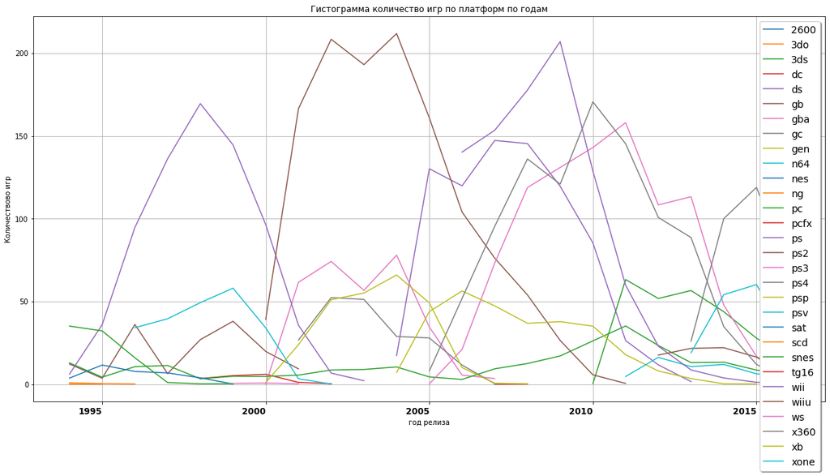

```python
#построим график распределения для всех платформ и посмотрим их сроки жизни
data0.pivot_table(index='year_of_release',
            columns = 'platform', values='total_sales',
            aggfunc='sum').plot(figsize=(20, 10))
plt.legend(fontsize=14, shadow=True,
           framealpha=1)
plt.xlabel('год релиза')
plt.grid()
plt.ylabel('Количествово игр')
plt.title('Гистограмма количество игр по платформ по годам')
plt.xticks(color='black', fontweight='bold', fontsize='12', horizontalalignment='right')

plt.show()
```

```python
# выводим на экран верх таблицы
data0.head()
```

|  | index | name | platform | year_of_release | genre | na_sales | eu_sales | jp_sales | other_sales | critic_score | user_score | rating | total_sales |
| --- | --- | --- | --- | --- | --- | --- | --- | --- | --- | --- | --- | --- | --- |
| 0 | 0 | wii sports | wii | 2006 | Sports | 41.36 | 28.96 | 3.77 | 8.45 | 76.0 | 8.0 | E | 82.54 |
| 1 | 2 | mario kart | wii | 2008 | Racing | 15.68 | 12.76 | 3.79 | 3.29 | 82.0 | 8.3 | E | 35.52 |
| 2 | 3 | wii sports resort | wii | 2009 | Sports | 15.61 | 10.93 | 3.28 | 2.95 | 80.0 | 8.0 | E | 32.77 |
| 3 | 4 | pokemon red/pokemon blue | gb | 1996 | Role-Playing | 11.27 | 8.89 | 10.22 | 1.00 | NaN | NaN | unknown | 31.38 |
| 4 | 6 | new super mario bros. | ds | 2006 | Platform | 11.28 | 9.14 | 6.50 | 2.88 | 89.0 | 8.5 | E | 29.80 |

Построим график распределения самых продаваемых (удачных) платформ из топ10

```python
#создаем список платформ из топ10
study_list = ['ps2', 'x360', 'ps3', 'wii', 'ds', 'ps', 'ps4',  'gba', 'psp', 'pc']
# делаем срез данных, оставляем только топ10 платформ
data0 = data0.query('platform==@study_list').reset_index()
# выводим на экран верх таблицы
data0.head()
```

|  | level_0 | index | name | platform | year_of_release | genre | na_sales | eu_sales | jp_sales | other_sales | critic_score | user_score | rating | total_sales |
| --- | --- | --- | --- | --- | --- | --- | --- | --- | --- | --- | --- | --- | --- | --- |
| 0 | 0 | 0 | wii sports | wii | 2006 | Sports | 41.36 | 28.96 | 3.77 | 8.45 | 76.0 | 8.0 | E | 82.54 |
| 1 | 1 | 2 | mario kart | wii | 2008 | Racing | 15.68 | 12.76 | 3.79 | 3.29 | 82.0 | 8.3 | E | 35.52 |
| 2 | 2 | 3 | wii sports resort | wii | 2009 | Sports | 15.61 | 10.93 | 3.28 | 2.95 | 80.0 | 8.0 | E | 32.77 |
| 3 | 4 | 6 | new super mario bros. | ds | 2006 | Platform | 11.28 | 9.14 | 6.50 | 2.88 | 89.0 | 8.5 | E | 29.80 |
| 4 | 5 | 7 | wii play | wii | 2006 | Misc | 13.96 | 9.18 | 2.93 | 2.84 | 58.0 | 6.6 | E | 28.91 |

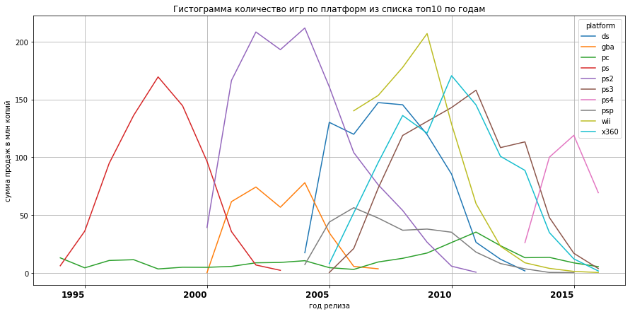

```python
# построим график распределения самых продаваемых (удачных) платформ из топ10
data0.pivot_table(index='year_of_release', columns = 'platform', values='total_sales',
                  aggfunc='sum').plot(figsize=(15, 7))
plt.xlabel('год релиза')
plt.grid()
plt.ylabel('сумма продаж в млн копий')
plt.title('Гистограмма количество игр по платформ из списка топ10 по годам')
plt.xticks(color='black', fontweight='bold', fontsize='12', horizontalalignment='right')

plt.show()
```

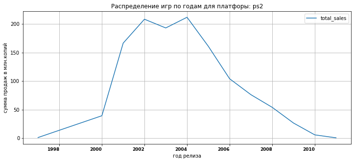

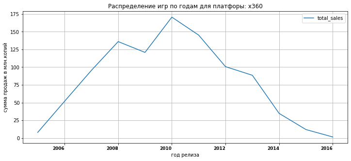

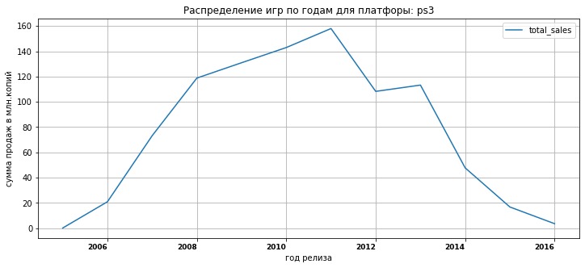

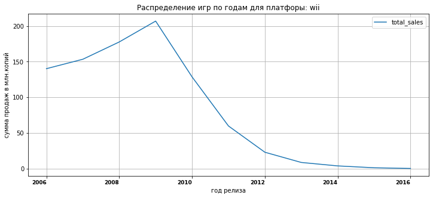

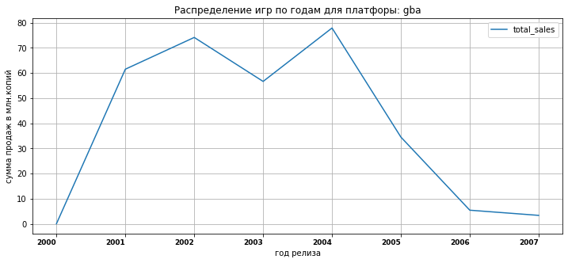

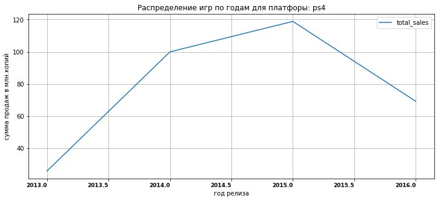

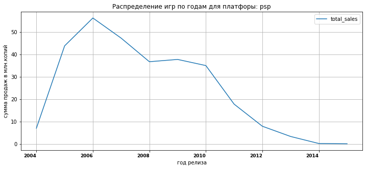

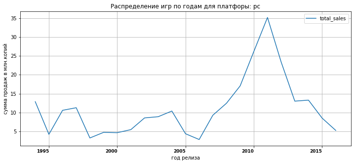

```python
#рассмотрим поподробнее распределение по годам по платфформам.
platform_list = ['ps2', 'x360', 'ps3', 'wii', 'gba', 'ps4', 'psp', 'pc']
for elem in platform_list:
    (data0
         .query('platform == @elem')#делаем срез
         .pivot_table(index='year_of_release', values='total_sales', aggfunc='sum')
         .plot(figsize=(12, 5), title='Распределение игр по годам для платфоры: '+elem)
    )
    plt.xlabel('год релиза')
    plt.grid()
    plt.ylabel('сумма продаж в млн.копий')
    plt.xticks(color='black', fontweight='bold', fontsize='9', horizontalalignment='right')
```

#### Вывод:

Рассматривая графики мы видим, что самой долгоживущей платформой является персональный компьютер, потому что развитие платформ консолей и модернизация "начинки" персонального компьютера - это 2 параллельные ветви развития платформ. Консоли - это мобильные девайсы, персональный компьютер - стационарное устройство. Однако модернизация консоли связана с полной ее заменой, а модернизация pc - это замена части его внутренностей. По стоимости скорее всего это сопоставимые суммы. Кроме того, консоль часто жертвует возможностями "железа" в пользу легкости, мобильности и дешевизны. Модернизация же персонального компьютера - имеет более разнообразный характер, и может подстроиться под пользователя точнее. Поэтому такая платформа как PC никогда не закончит свое существование. А если учесть тот факт что в датасете нет ноутбуков, то, вполне вероятно что они тоже попали в платформу PC, тогда можно с уверенностью говорить что и по мобильности PC догоняет своих конкурентов.

За какой характерный срок появляются новые и исчезают старые платформы?

```python
#продолжительность существования платформ
data_tmp = (data0
            .query('platform in @platform_list')
            .sort_values('year_of_release')
            .pivot_table(index='platform', values='year_of_release', aggfunc=['first', 'last'])
)
data_tmp['period_of_existence'] = data_tmp['last'] - data_tmp['first']
display(data_tmp.sort_values(by='period_of_existence',ascending=False))
print('медианный срок жизни платформ ', data_tmp['period_of_existence'].median())
```

| platform | first year_of_release | last year_of_release | period_of_existence |
| --- | --- | --- | --- |
| pc | 1994 | 2016 | 22 |
| ps2 | 1997 | 2011 | 14 |
| ps3 | 2005 | 2016 | 11 |
| psp | 2004 | 2015 | 11 |
| x360 | 2005 | 2016 | 11 |
| wii | 2006 | 2016 | 10 |
| gba | 2000 | 2007 | 7 |
| ps4 | 2013 | 2016 | 3 |

```
медианный срок жизни платформ  11.0
```

#### Вывод:

Для корректного прогнозирования продаж консолей в 2017 году недостаточно тех данных что мы получили. На графике явно выраженная тенденция затухания продаж по многим из платформ. Срок жизни платформ составляет в среднем 11 лет, на графике видно что бывает и больше. Для дальнейшего исследования необходимо погрузиться в тему платформ и структурировать их по типу: домашняя-мобильная, по производителю: Сони, Нинтендо, Майкрософт. Дополнительно необходимо определить смежные области кроме игровых консолей, где могут запускаться видеоигры, досконально исследовать не имеет смысла, но определить периоды роста продаж, появления их и, соответственно, влияние их на рынок консолей необходимо. Кроме того на рынок консолей влияет соотношение хардкордных игроков и казуальных, развитие стриминговых сервисов и мобильных приложений. Также на рынок игровых платформ влияет развитие рынка ПК, периферийных устройств и направление развития игровых сервисов (дополненная реальность, VR, фитнес-приложения). Без этих данных прогнозировать рост или снижение продаж какой-либо платформы для видеоигр не получится. Кроме того для прогнозирования необходимо определить тотальные продажи по всем платформам у каждого производителя, выявить лидеров, оценить суммарный бюджет по всем консолям и определить, в контрольной точке исследования 20017 год - тенденции рынка, в ретроспективе можно соотнести на какие смежные области рынка вышли компании (допустим трех лидеров рынка) - после этого можно будет спрогнозировать рост или снижение объемов продаж скорее всего последних версий платформ этих производителей. Если компания производитель выходит на новые рынки, соответственно можно предположить, что бюджет будет частично распределен на новые проекты, и консоли "потеряют" деньги на развитие, что также скажется на продажах.

в интеренете нашла производителей платформ - вот он:

PCFX:NECб  
GG:спортивный портал  
3DO:компаниями Panasonic, Sanyo, Creative и Goldstar  
TG16:NEC Home Electronics  
WS:  
NG:японской компанией SNK  
SCD:  
DC:sega  
GEN:sega  
SAT:sega  
PSV:Sony  
WiiU:Nintendo  
2600:Atari  
XOne:Microsoft  
GC:Nintendo  
SNES:Nintendo  
N64:Nintendo  
NES:Nintendo  
GB:Nintendo  
XB:Microsoft  
3DS:Nintendo  
PC:персональный компьютер (ПК)  
PSP:Sony  
PS4:Sony  
GBA:Nintendo  
PS:Sony  
DS:Nintendo  
Wii:Nintendo  
PS3:Sony  
X360:Microsoft  
PS2:Sony  
Создадим дополнительный список производителей в порядке их размещения в датасете согласно платформ. Изначально он пуст, затем добавляем в него циклом значения. Список передаем в столбец датафтейма с названием 'manufacturer'

```python
# создаем столбец производитель manufacturer в таблице data2
data_manufacturer = []
for row in data2['platform']:
    if row in ['dc', 'gen', 'sat'] : data_manufacturer.append('sega')
    elif row in ['wiiu','gc', 'snes', 'n64', 'nes', 'gb', '3ds', 'gba', 'ds', 'wii']:   data_manufacturer.append('nintendo')
    elif row in ['xone', 'xb','x360']: data_manufacturer.append('microsoft')
    elif row in ['psv', 'psp', 'ps4', 'ps', 'ps3', 'ps2']: data_manufacturer.append('sony')
    elif row in ['pc']:  data_manufacturer.append('персональный компьютер (пк)')
    else:  data_manufacturer.append('no_name')
data2['manufacturer'] = data_manufacturer
```

```python
# смотрим какие уникальные производителя попали в наш столбец, все верно как мы и планировали
data2['manufacturer'].unique()
```

```
array(['nintendo', 'microsoft', 'sony', 'персональный компьютер (пк)',
       'no_name', 'sega'], dtype=object)
```

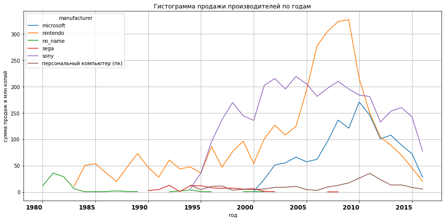

```python
# оставим в выгрузке только нужные года
data3 = data2.query("1980 <= year_of_release <= 2017")
#построим график распределения по производителям
data3.pivot_table(index='year_of_release',
                  columns = 'manufacturer', values='total_sales',
                  aggfunc='sum').plot(figsize=(15, 7))
plt.xlabel('год')
plt.grid()
plt.ylabel('сумма продаж в млн копий')
plt.title('Гистограмма продажи производителей по годам')
plt.xticks(color='black', fontweight='bold', fontsize='12', horizontalalignment='right')
plt.show()
```

### 3.3. Определение актуального периода

К плану работ

Возьмем данные за актуальный период полученный в результате исследования предыдущих вопросов. Поскольку цикл жизни платформ Основной фактор для выделения актуального периода — эти данные помогут построить прогноз на 2017 год. Не будем учитывать в работе данные за предыдущие годы. Ответим на вопрос: Какие платформы лидируют по продажам, растут или падают? Выберем несколько потенциально прибыльных платформ.

```python
# выбираем актуальный период 2011-2016гг включително
data_actual_period = data2.query('2010 < year_of_release < 2017')
# смотрим пропуски в таблице с данными за актуальный период
print(data_actual_period.isna().sum())
# выводим верх таблицы на экран
display(data_actual_period.head())
```

```
name                  0
platform              0
year_of_release       0
genre                 0
na_sales              0
eu_sales              0
jp_sales              0
other_sales           0
critic_score       2223
user_score         2004
rating                0
total_sales           0
manufacturer          0
dtype: int64
```

|  | name | platform | year_of_release | genre | na_sales | eu_sales | jp_sales | other_sales | critic_score | user_score | rating | total_sales | manufacturer |
| --- | --- | --- | --- | --- | --- | --- | --- | --- | --- | --- | --- | --- | --- |
| 16 | grand theft auto v | ps3 | 2013 | Action | 7.02 | 9.09 | 0.98 | 3.96 | 97.0 | 8.2 | M | 21.05 | sony |
| 23 | grand theft auto v | x360 | 2013 | Action | 9.66 | 5.14 | 0.06 | 1.41 | 97.0 | 8.1 | M | 16.27 | microsoft |
| 29 | call of duty: modern warfare 3 | x360 | 2011 | Shooter | 9.04 | 4.24 | 0.13 | 1.32 | 88.0 | 3.4 | M | 14.73 | microsoft |
| 31 | call of duty: black ops 3 | ps4 | 2015 | Shooter | 6.03 | 5.86 | 0.36 | 2.38 | NaN | NaN | unknown | 14.63 | sony |
| 33 | pokemon x/pokemon y | 3ds | 2013 | Role-Playing | 5.28 | 4.19 | 4.35 | 0.78 | NaN | NaN | unknown | 14.60 | nintendo |

#### Вывод:

Мы взяли за актуальный период для прогноза на 2017 год данные с 2011 по 2016 года включительно. 2011 год выхода первого айфона и старт эры смартфонов. 2016 - это последний год данных в таблице, часто он самый важный в прогнозах. Пропуски в таблице только в столбцах оценок критиков и оценок пользователей.

### 3.4. Определение потенциально прибыльных платформ

К плану работ

```
Продажи по платформам в актуальный период:
platform
ps3     447.68
x360    382.75
ps4     314.14
3ds     258.21
xone    159.32
pc       98.59
wii      96.39
wiiu     82.19
psv      53.81
ds       39.54
psp      29.51
ps2       0.45
Name: total_sales, dtype: float64
```

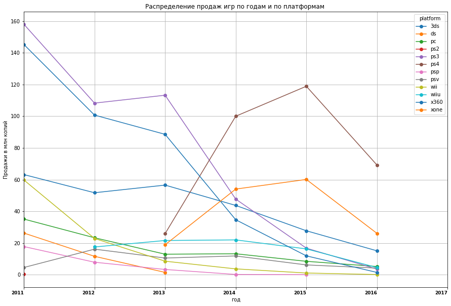

```python
data_group_platform_sales = data_actual_period.groupby('platform')['total_sales'].sum()
print('Продажи по платформам в актуальный период:\n', data_group_platform_sales.sort_values(ascending=False), sep='')

data_actual_period.pivot_table(index='year_of_release',
        columns = 'platform', values='total_sales', aggfunc='sum').plot(style='o-', figsize=(15, 10), xlim=(2011, 2017),
        title='Распределение продаж игр по годам и по платформам ')
plt.xlabel('год')
plt.grid()
plt.ylabel('Продажи в млн копий')
plt.xticks(color='black', fontweight='bold', fontsize='9', horizontalalignment='right')

plt.show()
```

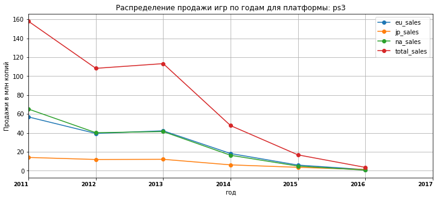

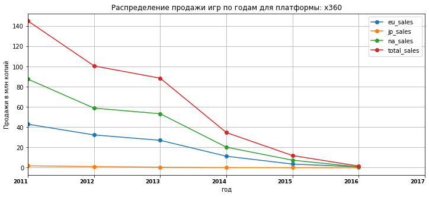

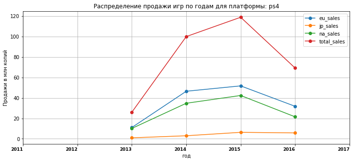

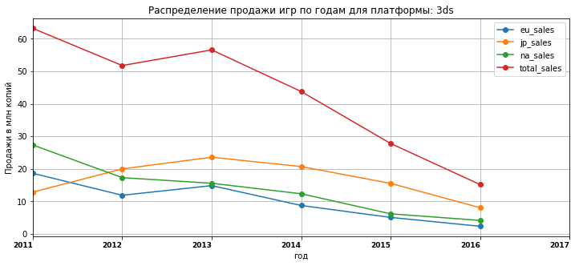

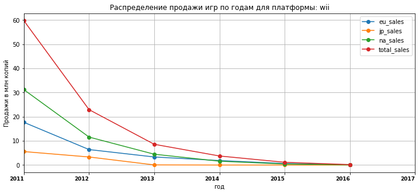

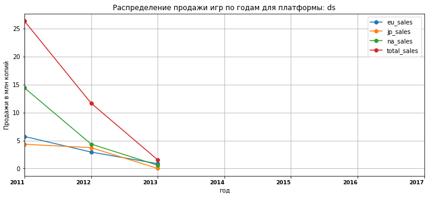

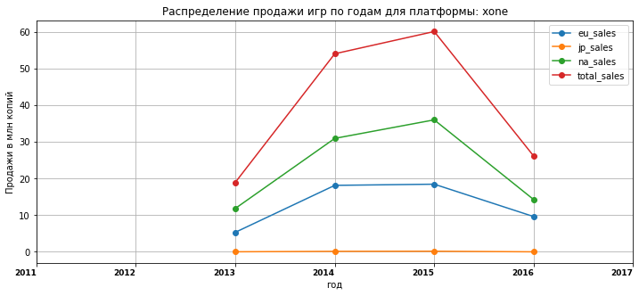

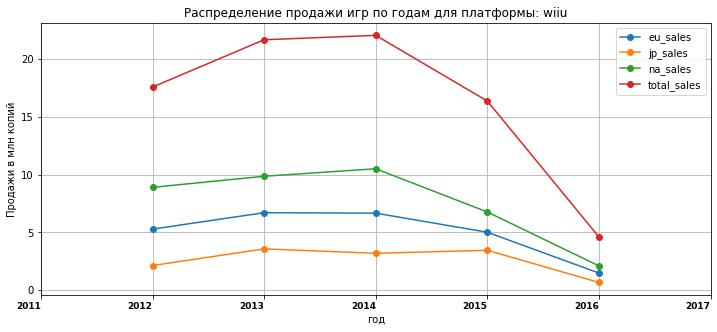

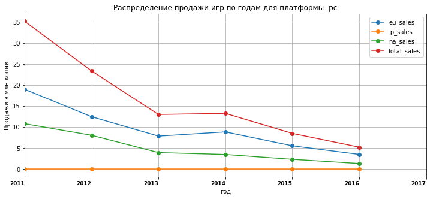

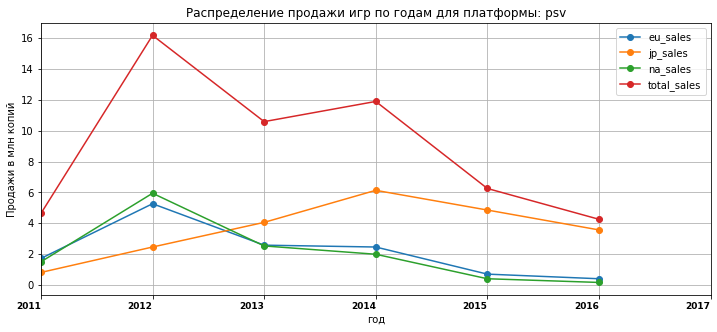

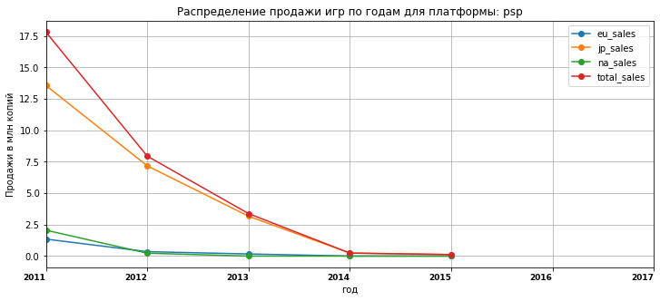

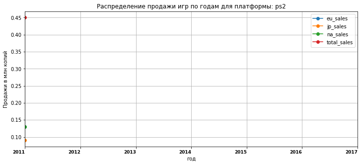

```python
# построим эти графики каждый отдельно
for elem in data_actual_period['platform'].unique():
    (data_actual_period
         .query('platform == @elem')#делаем срез
         .pivot_table(index='year_of_release', values=['total_sales', 'na_sales', 'eu_sales', 'jp_sales'], aggfunc='sum')
         .plot(style='o-', grid=True, figsize=(12, 5), xlim=(2011, 2017),
               title='Распределение продажи игр по годам для платформы: '+elem)
    )
    plt.xlabel('год')
    plt.ylabel('Продажи в млн копий')
    plt.xticks(color='black', fontweight='bold', fontsize='9', horizontalalignment='right')

    plt.show()
```